# Name: Toh Kien Yu Admin Number: 2222291 Class: DAAA/FT/2B/05

## Background Research

### Next-word prediction is a language modeling task in machine learning to predict the most likely word or a set of words that will come after a given input context. This is widely used in real-life application such as the auto-complete feature on our smartphones, speech recognition system and more. To sum it up, next-word prediction has accelerated our efficiency, accessibility and improved user experience.

## Loading Dataset

```python
# Read data.

import pandas as pd

data = pd.read_csv('train.csv')

print(data)
# Convert data to a list.
data = list(data.Quotes.values)
print(f'There are {len(data)} quotes in this dataset.')
print(data[:5])
```

```
                                                Quotes
0    Embrace the beauty of every sunrise; it's a fr...
1    Embrace challenges; they are the stepping ston...
2    Embrace the rhythm of life and let it dance th...
3    Embrace kindness, for it has the power to chan...
4    Embrace the journey, for it leads to the desti...
..                                                 ...
995  With an open heart, welcome the opportunities ...
996  This morning, let your laughter be the music t...
997  In the serenity of this morning, find the powe...
998  This morning, let your actions be a testament ...
999  With each sunrise, this morning offers the pro...

[1000 rows x 1 columns]
There are 1000 quotes in this dataset.
["Embrace the beauty of every sunrise; it's a fresh chance to paint your world with joy.", 'Embrace challenges; they are the stepping stones to your greatest victories.', 'Embrace the rhythm of life and let it dance through your soul.', 'Embrace kindness, for it has the power to change the world one…
```

```python
# Convert data to a Data Frame
df = pd.DataFrame(data,columns=['Quotes'])
df
```

|  | Quotes |
| --- | --- |
| 0 | Embrace the beauty of every sunrise; it's a fr... |
| 1 | Embrace challenges; they are the stepping ston... |
| 2 | Embrace the rhythm of life and let it dance th... |
| 3 | Embrace kindness, for it has the power to chan... |
| 4 | Embrace the journey, for it leads to the desti... |
| ... | ... |
| 995 | With an open heart, welcome the opportunities ... |
| 996 | This morning, let your laughter be the music t... |
| 997 | In the serenity of this morning, find the powe... |
| 998 | This morning, let your actions be a testament ... |
| 999 | With each sunrise, this morning offers the pro... |

1000 rows × 1 columns

## Feature Engineering

```python
# Tokenisation.
from tensorflow.keras.preprocessing.text import Tokenizer
# Instantiate a Tokenizer object.
tokenizer = Tokenizer(oov_token='<oov>') # Instantiate a Tokenizer object.
# Fit Tokenizer on the dataset. This will map words in your dataset to integers.
tokenizer.fit_on_texts(df['Quotes'])
print(tokenizer.word_index)
```

```
{'<oov>': 1, 'the': 2, 'of': 3, 'your': 4, 'and': 5, 'a': 6, 'in': 7, 'is': 8, 'for': 9, 'let': 10, 'be': 11, 'it': 12, 'to': 13, 'every': 14, 'you': 15, 'our': 16, 'that': 17, 'dance': 18, "life's": 19, 'embrace': 20, 'through': 21, 'this': 22, 'with': 23, 'believe': 24, 'are': 25, 'radiate': 26, '…
```

```python
# The following for-loop converts each of the 1000 quotes from texts to integers.
input_sequences = []

for datapoint in df['Quotes']:
    token_list = tokenizer.texts_to_sequences([datapoint])[0]


    for i in range(1,len(token_list)):
        nGramSequence = token_list[:i+1]
        input_sequences.append(nGramSequence)

print(f'Total number of quotes: {len(input_sequences)}')
```

```
Total number of quotes: 10886
```

```python
import numpy as np
from tensorflow.keras.preprocessing.sequence import pad_sequences
max_sequence_len = max([len(x) for x in input_sequences])
input_sequences = np.array(pad_sequences(input_sequences, maxlen=max_sequence_len, padding='pre'))
```

```python
total_words = len(tokenizer.word_index) + 1 # Because index 0 is reserved for padding.
print(total_words)
```

```
1200
```

### Defining X and y

```python
from tensorflow.keras.preprocessing.sequence import pad_sequences
import numpy as np
from tensorflow.keras import utils
X = input_sequences[:,:-1]
y = input_sequences[:,-1]
y = utils.to_categorical(y, num_classes=total_words)
```

```python
# Total number of words
print(f'Total Words: {total_words}')
# Shape of X and y
print(f'Shape of X: {X.shape}')
print(f'Shape of y: {y.shape}')
```

```
Total Words: 1200
Shape of X: (10886, 34)
Shape of y: (10886, 1200)
```

## Utilities

### Function to plot model's accuracy and loss graph

```python
import matplotlib.pyplot as plt
def plotAUC(model):
    fig = plt.figure(figsize = (18,7))
    fig.set_facecolor('lightblue')
    fig.suptitle('Accuracy and Loss Graph')
    ax1 = fig.add_subplot(1,2,1)
    ax1.set_title('Model Accuracy')
    ax1.set_xlabel('Epoch')
    ax1.set_ylabel('Accuracy')
    ax1.plot(model.history['accuracy'])
    ax2 = fig.add_subplot(1,2,2)
    ax2.set_title('Model Loss')
    ax2.set_xlabel('Epoch')
    ax2.set_ylabel('Loss')
    ax2.plot(model.history['loss'])
    plt.tight_layout()
    plt.show()
```

### Function to predict the next 'n' number of words

```python
def predict_next_N_words(model,input_text,N_words=10,temperature=0.5):
    outputSequence = input_text.split()
    for i in range(N_words):
        tokens = tokenizer.texts_to_sequences([outputSequence])[0]
        tokens = pad_sequences([tokens], maxlen=max_sequence_len-1, padding='pre')

        prediction = model.predict(tokens, verbose=0)
        prediction = np.log(prediction) / temperature
        prediction = np.exp(prediction) / np.sum(np.exp(prediction))
        predictedWord = np.random.choice(np.arange(len(prediction[0])), p=prediction[0])
        predictedWord = tokenizer.sequences_to_texts([[predictedWord]])[0]



        outputSequence.append(predictedWord)

    predictedText = ' '.join(outputSequence)
    return predictedText
```

## Model 1

### Model 1 is designed to be a simple LSTM model, dropout was added to handle overfitting

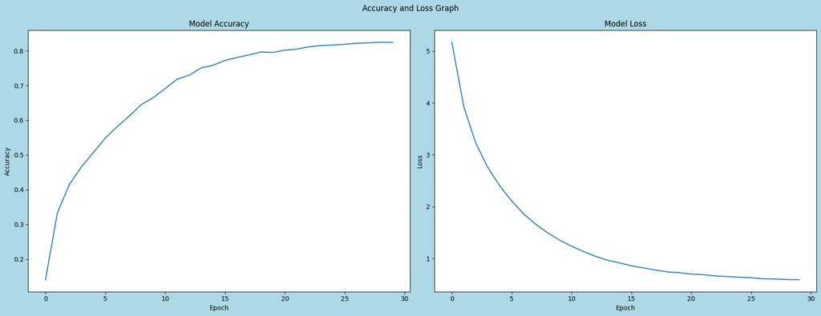

```python
from tensorflow.keras.layers import Embedding, LSTM, Dense, Dropout
from tensorflow.keras.models import Sequential

import tensorflow as tf
gpus = tf.config.experimental.list_physical_devices('GPU')
for gpu in gpus:
    tf.config.experimental.set_memory_growth(gpu, True)

# Input is max sequence length - 1, as we've removed the last word for the label.
input_len = max_sequence_len - 1

model = Sequential()

# Add input embedding layer.
model.add(Embedding(total_words, 256, input_length=input_len))

# Add LSTM layer with 256 units.
model.add(LSTM(256))

# Control overfitting.
model.add(Dropout(0.3))

# Add output layer
model.add(Dense(total_words, activation='softmax'))
model.compile(loss='categorical_crossentropy', optimizer='adam',metrics=['accuracy'])
history = model.fit(X, y, epochs=30, verbose=1,batch_size=32)
model.save_weights("./RNN Weights/model1.h5")
plotAUC(history)
```

### Model 1 Summary

```python
model.summary()
```

```
Model: "sequential_56"
_________________________________________________________________
 Layer (type)                Output Shape              Param #
=================================================================
 embedding_56 (Embedding)    (None, 34, 256)           307200

 lstm_65 (LSTM)              (None, 256)               525312

 dropout_65 (Dropout)        (None, 256)               0

 dense_59 (Dense)            (None, 1200)              308400

=================================================================
Total params: 1,140,912
Trainable params: 1,140,912
Non-trainable params: 0
_________________________________________________________________
```

## Model 1 Evaluation

### We will evaluate how meaningful the generated sequence of words, how creative they are using seed_texts Metrics: 1. BLEU Score (BiLingual Evaluation Understudy) measures the similarity of the machine's output text to a set of referenced translation. 2. Jaccard Similarity is a measure of similarity between 2 sets. 3. Human Evaluation involves obtaining input from human to assess the quality and creativity of the generated sequences.

## Reference Text

```python
referenceDF = df.copy()
pointer = 0
reference_texts = []
while pointer<1000:
    reference_texts.extend((referenceDF[pointer:pointer+10]['Quotes'].values.tolist()))
    pointer += 100
reference_texts
```

```
["Embrace the beauty of every sunrise; it's a fresh chance to paint your world with joy.",
 'Embrace challenges; they are the stepping stones to your greatest victories.',
 'Embrace the rhythm of life and let it dance through your soul.',
 'Embrace kindness, for it has the power to change the world one heart at a time.',
 'Embrace the journey, for it leads to the destination of your dreams.',
 'Embrace your uniqueness, for it is the fingerprint of your soul on the universe.',
 'Embrace the present moment, for it is the only one that truly exists.',
 'Embrace your fears, for they hold the key to unlocking your true potential.',
 'Embrace gratitude, and watch how it multiplies the blessings in your life.',
 'Embrace the rain, for it nourishes the seeds of your future success.',
 'Radiate positivity, and watch how it illuminates your world.',
 'Radiate kindness, for it has the power to transform hearts and minds.',
 'Radiate love, for it is the most powerful force in the universe.',
 "Radiate gratitude, and you'll attract more blessings into your life.",
 'Radiate confidence, for it is the key to unlocking your true potential.',
 'Radiate joy, and let it light up the lives of those around you.',
 'Radiate authenticity, for it is the essence of true beauty.',
 'Radiate peace, and create a sanctuary of serenity within you.',
 'Radiate resilience, and let it be the armor that shields your heart.',
 'Radiate wisdom, for it carries the light of experience.',
 'Believe in yourself, for you are capable of greatness.',
 'Believe in yourself, and you will be unstoppable.',
 'Believe in yourself, and the world will believe in you.',
 'Believe in yourself, and you will conquer any challenge.',
 'Believe in yourself, for you hold the power within.',
 'Believe in yourself, and your dreams will take flight.',
 'Believe in yourself, and let your light shine bright.',
 'Believe in yourself, and miracles will happen.',
 'Believe in yourself, and you will find your way.',
 'Believe in yourself, and magic will follow.',
 "Life's journey is a canvas; paint it with vibrant experiences.",
 "Life's challenges are stepping stones to wisdom and growth.",
 "Life's melodies are composed of moments that touch the soul.",
 "Life's colors are brightest when painted with love and kindness.",
 "Life's adventures are the chapters that make our story extraordinary.",
 "Life's storms are followed by rainbows of hope and resilience.",
 "Life's garden blooms with the seeds of kindness we plant.",
 "Life's music is the symphony of laughter and joy.",
 "Life's whispers hold the secrets of the universe within them.",
 "Life's dance is more beautiful when we move with grace and gratitude.",
```

[output cut: 45 more lines]

```
 "Our planet's landscapes are a tapestry woven with threads of life.",
 'In the whispers of the wind, we hear the soulful song of our planet.',
 'Every tree is a testament to the strength and resilience of our planet.',
 "Our planet's oceans hold secrets and mysteries waiting to be explored.",
 'In the dance of seasons, we witness the ever-changing face of our planet.',
 'This morning holds the promise of a brand new day, full of possibilities.',
 'In the gentle embrace of this morning, we find the magic of new beginnings.',
 'This morning, let gratitude be your first thought, and joy will follow.',
 'With each sunrise, this morning paints the sky with colors of hope.',
 "This morning, let kindness be the compass guiding your day's journey.",
 "In the stillness of this morning, hear the whispers of your heart's desires.",
 'This morning, let your smile light up the world like the rising sun.',
 'With every breath this morning, inhale peace, exhale gratitude.',
 'This morning, let your actions be a testament to the goodness in your heart.',
 'In the quietude of this morning, find solace in the beauty of simplicity.']
```

## Bleu Score

### A higher temperature will result in a lower BLEU Score due to the diversity of text it will generate

```python
from rouge_score import rouge_scorer
from nltk.translate.bleu_score import sentence_bleu,SmoothingFunction

seed_texts = ['embrace each day',
 'radiate some',
 'believe that',
 "life's actual purpose is",
 'dance through each and every',
 'let your time and energy',
 'every person is',
 'our country Singapore is',
 'planet earth is',
 'morning and evening would make it']
generatedTexts = [predict_next_N_words(model,seed,10,0.8) for seed in seed_texts]
smoothie = SmoothingFunction().method1

for reference_text,generated in zip(reference_texts,generatedTexts):
    reference = [reference_text.split()]
    candidate = generated.split()
    bleuScore = sentence_bleu(reference,candidate,weights=(1,0,0,0),smoothing_function=smoothie)

    print(f"Generated Text: {generated}")
    print(f"BLEU Score: {bleuScore:.4f}\n")
```

```
Generated Text: embrace each day with a heart full of gratitude and compassion your future
BLEU Score: 0.2443

Generated Text: radiate some for it is the language of the soul and soul
BLEU Score: 0.0833

Generated Text: believe that kindness be the light that brightens someone's day leaving a
BLEU Score: 0.0833

Generated Text: life's actual purpose is a testament to the resilience of our planet's future are
BLEU Score: 0.1858

Generated Text: dance through each and every moment of laughter for it is where true beauty and
BLEU Score: 0.2000

Generated Text: let your time and energy the light that makes someone's day brighter future in the
BLEU Score: 0.2000

Generated Text: every person is a reminder of the gift of life and our planet
BLEU Score: 0.1538

Generated Text: our country Singapore is a canvas for the soul and nourishes of our inner
BLEU Score: 0.1429

Generated Text: planet earth is a reminder of the heart of our journey and growth
BLEU Score: 0.1538

Generated Text: morning and evening would make it holds the promise of becoming reality of becoming reality and
BLEU Score: 0.1875
```

## Jaccard Similarity

```python
from rouge_score import rouge_scorer
from nltk.translate.bleu_score import sentence_bleu,SmoothingFunction

# reference: https://www.educative.io/answers/what-is-the-jaccard-similarity-measure-in-nlp

def jaccardSimilarity(set1,set2):
    intersection = len(set1.intersection(set2))
    union = len(set1.union(set2))
    similarity = intersection/union if union!= 0 else 0
    return similarity


for reference_text,generated in zip(reference_texts,generatedTexts):
    reference = set(reference_text.split())
    candidate = set(generated.split())
    jaccardResult = jaccardSimilarity(reference,candidate)

    print(f"Generated Text: {generated}")
    print(f"Jaccard Similarity: {jaccardResult:.4f}\n")
```

```
Generated Text: embrace each day with a heart full of gratitude and compassion your future
Jaccard Similarity: 0.1600

Generated Text: radiate some for it is the language of the soul and soul
Jaccard Similarity: 0.0500

Generated Text: believe that kindness be the light that brightens someone's day leaving a
Jaccard Similarity: 0.0455

Generated Text: life's actual purpose is a testament to the resilience of our planet's future are
Jaccard Similarity: 0.1154

Generated Text: dance through each and every moment of laughter for it is where true beauty and
Jaccard Similarity: 0.1364

Generated Text: let your time and energy the light that makes someone's day brighter future in the
Jaccard Similarity: 0.0833

Generated Text: every person is a reminder of the gift of life and our planet
Jaccard Similarity: 0.0909

Generated Text: our country Singapore is a canvas for the soul and nourishes of our inner
Jaccard Similarity: 0.0870

Generated Text: planet earth is a reminder of the heart of our journey and growth
Jaccard Similarity: 0.0909

Generated Text: morning and evening would make it holds the promise of becoming reality of becoming reality and
Jaccard Similarity: 0.1500
```

## Human Evaluation

### I will be assessing the generated text based on the relevance, meaningfulness and creativity corresponding to the seed text. To achieve unique generated texts, I will use the model to generate the text twice.

### First run

```python
generatedTexts = [predict_next_N_words(model,seed,10,0.8) for seed in seed_texts]
print("1st Run")
for seed,generated in zip(seed_texts,generatedTexts):
    print(f"Seed Text: {seed}")
    print(f"Generated Text: {generated}\n")
```

```
1st Run
Seed Text: embrace each day
Generated Text: embrace each day springs take a new day filled with endless possibilities that

Seed Text: radiate some
Generated Text: radiate some and let it be the sunrise in your darkest nights

Seed Text: believe that
Generated Text: believe that you will be a testament to your indomitable spirit a

Seed Text: life's actual purpose is
Generated Text: life's actual purpose is the harmonious of our inner strength and wisdom for it

Seed Text: dance through each and every
Generated Text: dance through each and every challenge overcome is a testament to your indomitable spirit a

Seed Text: let your time and energy
Generated Text: let your time and energy the light that brightens the way around you encounter give

Seed Text: every person is
Generated Text: every person is a reminder of the journey of life on our planet

Seed Text: our country Singapore is
Generated Text: our country Singapore is a tapestry woven with threads of resilience and resilience of

Seed Text: planet earth is
Generated Text: planet earth is a symphony of gratitude for it for it is the

Seed Text: morning and evening would make it
Generated Text: morning and evening would make it holds the promise of blossoming of blooming into reality of
```

### Second Run

```python
generatedTexts = [predict_next_N_words(model,seed,10,0.8) for seed in seed_texts]
print("Second Run")
for seed,generated in zip(seed_texts,generatedTexts):
    print(f"Seed Text: {seed}")
    print(f"Generated Text: {generated}\n")
```

```
Second Run
Seed Text: embrace each day
Generated Text: embrace each day brings new opportunities to shine for our planet's future and

Seed Text: radiate some
Generated Text: radiate some for it is the foundation of your being genuine on

Seed Text: believe that
Generated Text: believe that yourself and you will be a beacon of light for

Seed Text: life's actual purpose is
Generated Text: life's actual purpose is the character of a joyful heart at the soul of

Seed Text: dance through each and every
Generated Text: dance through each and every touch the safari's from your journey a tale worth telling

Seed Text: let your time and energy
Generated Text: let your time and energy the light that brightens someone's day leaving a trail of

Seed Text: every person is
Generated Text: every person is a celebration of the hope and potential within our planet

Seed Text: our country Singapore is
Generated Text: our country Singapore is a testament to the nation's resilience and unwavering determination and

Seed Text: planet earth is
Generated Text: planet earth is a symphony of joy a symphony of joy that reverberates

Seed Text: morning and evening would make it
Generated Text: morning and evening would make it holds the promise of blossoming of blooming into reality of
```

### Most Meaningful, Creative and Relevant: Generated Text: embrace each day brings new opportunities to shine for our planet's future and Most Relevant: Generated Text: every person is a celebration of the hope and potential within our planet Less Relevant: Generated Text: let your time and energy the light that brightens someone's day leaving a trail of

## Load Model 1

```python
from tensorflow.keras.layers import Embedding, LSTM, Dense, Dropout
from tensorflow.keras.models import Sequential

import tensorflow as tf
gpus = tf.config.experimental.list_physical_devices('GPU')
for gpu in gpus:
    tf.config.experimental.set_memory_growth(gpu, True)

# Input is max sequence length - 1, as we've removed the last word for the label.
input_len = max_sequence_len - 1

model = Sequential()

# Add input embedding layer.
model.add(Embedding(total_words, 256, input_length=input_len))

# Add LSTM layer with 256 units.
model.add(LSTM(256))

# Control overfitting.
model.add(Dropout(0.3))

# Add output layer
model.add(Dense(total_words, activation='softmax'))
model.compile(loss='categorical_crossentropy', optimizer='adam',metrics=['accuracy'])
model.load_weights("./RNN Weights/model1.h5")
```

## Model 2

### For Model 2, I will experiment with GRU (Gated Recurrent Units). Additionally, Bidirectional has been incorporated to enable the GRU to receive input from both forward and backward direction.

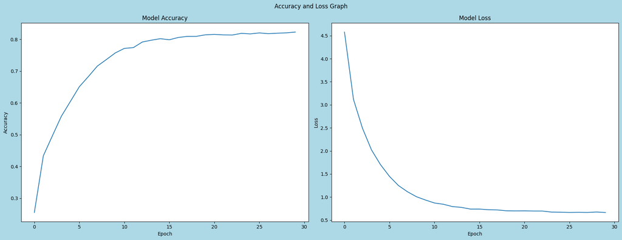

```python
from tensorflow.keras.layers import Embedding, LSTM, Dense, Dropout,GRU,Bidirectional
from tensorflow.keras.models import Sequential

import tensorflow as tf
gpus = tf.config.experimental.list_physical_devices('GPU')
for gpu in gpus:
    tf.config.experimental.set_memory_growth(gpu, True)

# Input is max sequence length - 1, as we've removed the last word for the label.
input_len = max_sequence_len - 1

model = Sequential()

# Add input embedding layer.
model.add(Embedding(total_words, 256, input_length=input_len))

# Add LSTM layer with 256 units.
model.add(Bidirectional(GRU(256,return_sequences=True)))
model.add(Bidirectional(GRU(256)))

# Control overfitting.
model.add(Dropout(0.3))

# Add output layer
model.add(Dense(total_words, activation='softmax'))
model.compile(loss='categorical_crossentropy', optimizer='adam',metrics=['accuracy'])
history = model.fit(X, y, epochs=30, verbose=1,batch_size=32)
model.save_weights("./RNN Weights/model2.h5")
plotAUC(history)
```

```python
model.summary()
```

```
Model: "sequential_57"
_________________________________________________________________
 Layer (type)                Output Shape              Param #
=================================================================
 embedding_57 (Embedding)    (None, 34, 256)           307200

 bidirectional_24 (Bidirecti  (None, 34, 512)          789504
 onal)

 bidirectional_25 (Bidirecti  (None, 512)              1182720
 onal)

 dropout_66 (Dropout)        (None, 512)               0

 dense_60 (Dense)            (None, 1200)              615600

=================================================================
Total params: 2,895,024
Trainable params: 2,895,024
Non-trainable params: 0
_________________________________________________________________
```

## Model 2 Evaluation

### We will evaluate how meaningful the generated sequence of words, how creative they are using referehce text Metrics: 1. BLEU Score (BiLingual Evaluation Understudy) measures the similarity of the machine's output text to a set of referenced translation. 2. Jaccard Similarity is a measure of similarity between 2 sets. 3. Human Evaluation involves obtaining input from human to assess the quality and creativity of the generated sequences.

## Reference Text

### Reference text was created by extracting the first 10 quotes from every set of 100 consecutive rows in the dataset.

```python
referenceDF = df.copy()
pointer = 0
reference_texts = []
while pointer<1000:
    reference_texts.extend((referenceDF[pointer:pointer+10]['Quotes'].values.tolist()))
    pointer += 100
reference_texts
```

```
["Embrace the beauty of every sunrise; it's a fresh chance to paint your world with joy.",
 'Embrace challenges; they are the stepping stones to your greatest victories.',
 'Embrace the rhythm of life and let it dance through your soul.',
 'Embrace kindness, for it has the power to change the world one heart at a time.',
 'Embrace the journey, for it leads to the destination of your dreams.',
 'Embrace your uniqueness, for it is the fingerprint of your soul on the universe.',
 'Embrace the present moment, for it is the only one that truly exists.',
 'Embrace your fears, for they hold the key to unlocking your true potential.',
 'Embrace gratitude, and watch how it multiplies the blessings in your life.',
 'Embrace the rain, for it nourishes the seeds of your future success.',
 'Radiate positivity, and watch how it illuminates your world.',
 'Radiate kindness, for it has the power to transform hearts and minds.',
 'Radiate love, for it is the most powerful force in the universe.',
 "Radiate gratitude, and you'll attract more blessings into your life.",
 'Radiate confidence, for it is the key to unlocking your true potential.',
 'Radiate joy, and let it light up the lives of those around you.',
 'Radiate authenticity, for it is the essence of true beauty.',
 'Radiate peace, and create a sanctuary of serenity within you.',
 'Radiate resilience, and let it be the armor that shields your heart.',
 'Radiate wisdom, for it carries the light of experience.',
 'Believe in yourself, for you are capable of greatness.',
 'Believe in yourself, and you will be unstoppable.',
 'Believe in yourself, and the world will believe in you.',
 'Believe in yourself, and you will conquer any challenge.',
 'Believe in yourself, for you hold the power within.',
 'Believe in yourself, and your dreams will take flight.',
 'Believe in yourself, and let your light shine bright.',
 'Believe in yourself, and miracles will happen.',
 'Believe in yourself, and you will find your way.',
 'Believe in yourself, and magic will follow.',
 "Life's journey is a canvas; paint it with vibrant experiences.",
 "Life's challenges are stepping stones to wisdom and growth.",
 "Life's melodies are composed of moments that touch the soul.",
 "Life's colors are brightest when painted with love and kindness.",
 "Life's adventures are the chapters that make our story extraordinary.",
 "Life's storms are followed by rainbows of hope and resilience.",
 "Life's garden blooms with the seeds of kindness we plant.",
 "Life's music is the symphony of laughter and joy.",
 "Life's whispers hold the secrets of the universe within them.",
 "Life's dance is more beautiful when we move with grace and gratitude.",
```

[output cut: 45 more lines]

```
 "Our planet's landscapes are a tapestry woven with threads of life.",
 'In the whispers of the wind, we hear the soulful song of our planet.',
 'Every tree is a testament to the strength and resilience of our planet.',
 "Our planet's oceans hold secrets and mysteries waiting to be explored.",
 'In the dance of seasons, we witness the ever-changing face of our planet.',
 'This morning holds the promise of a brand new day, full of possibilities.',
 'In the gentle embrace of this morning, we find the magic of new beginnings.',
 'This morning, let gratitude be your first thought, and joy will follow.',
 'With each sunrise, this morning paints the sky with colors of hope.',
 "This morning, let kindness be the compass guiding your day's journey.",
 "In the stillness of this morning, hear the whispers of your heart's desires.",
 'This morning, let your smile light up the world like the rising sun.',
 'With every breath this morning, inhale peace, exhale gratitude.',
 'This morning, let your actions be a testament to the goodness in your heart.',
 'In the quietude of this morning, find solace in the beauty of simplicity.']
```

## Bleu Score

```python
from rouge_score import rouge_scorer
from nltk.translate.bleu_score import sentence_bleu,SmoothingFunction
seed_texts = ['embrace each day',
 'radiate some',
 'believe that',
 "life's actual purpose is",
 'dance through each and every',
 'let your time and energy',
 'every person is',
 'our country Singapore is',
 'planet earth is',
 'morning and evening would make it']
generatedTexts = [predict_next_N_words(model,seed,10,0.8) for seed in seed_texts]
smoothie = SmoothingFunction().method1

for reference_text,generated in zip(reference_texts,generatedTexts):
    reference = [reference_text.split()]
    candidate = generated.split()
    bleuScore = sentence_bleu(reference,candidate,weights=(1,0,0,0),smoothing_function=smoothie)

    print(f"Generated Text: {generated}")
    print(f"BLEU Score: {bleuScore:.4f}\n")
```

```
Generated Text: embrace each day is a reminder of the gift of life and lightheartedness
BLEU Score: 0.1832

Generated Text: radiate some and let it be the wind in your darkest nights
BLEU Score: 0.1667

Generated Text: believe that harmony creating a symphony of love for the future of
BLEU Score: 0.1667

Generated Text: life's actual purpose is the blooms of resilience and strength that reside within you
BLEU Score: 0.0619

Generated Text: dance through each and every setback is a setup for a comeback a symbol of
BLEU Score: 0.1333

Generated Text: let your time and energy inspire the world around you forward it is the path
BLEU Score: 0.3333

Generated Text: every person is a beacon of hope for the future of our planet
BLEU Score: 0.2308

Generated Text: our country Singapore is a canvas painted with the brushstrokes of survival our planet
BLEU Score: 0.0714

Generated Text: planet earth is a symphony of joy in the gentle embrace of this
BLEU Score: 0.1538

Generated Text: morning and evening would make it is a mark of the light in our harmony around
BLEU Score: 0.1875
```

### The BLEU Score for Model 2 ranges from 0.3333 (highest) and 0.0619 (lowest)

## Jaccard Similarity

```python
from rouge_score import rouge_scorer
from nltk.translate.bleu_score import sentence_bleu,SmoothingFunction

# reference: https://www.educative.io/answers/what-is-the-jaccard-similarity-measure-in-nlp

def jaccardSimilarity(set1,set2):
    intersection = len(set1.intersection(set2))
    union = len(set1.union(set2))
    similarity = intersection/union if union!= 0 else 0
    return similarity


for reference_text,generated in zip(reference_texts,generatedTexts):
    reference = set(reference_text.split())
    candidate = set(generated.split())
    jaccardResult = jaccardSimilarity(reference,candidate)

    print(f"Generated Text: {generated}")
    print(f"Jaccard Similarity: {jaccardResult:.4f}\n")
```

```
Generated Text: embrace each day is a reminder of the gift of life and lightheartedness
Jaccard Similarity: 0.1200

Generated Text: radiate some and let it be the wind in your darkest nights
Jaccard Similarity: 0.0952

Generated Text: believe that harmony creating a symphony of love for the future of
Jaccard Similarity: 0.0952

Generated Text: life's actual purpose is the blooms of resilience and strength that reside within you
Jaccard Similarity: 0.0357

Generated Text: dance through each and every setback is a setup for a comeback a symbol of
Jaccard Similarity: 0.0909

Generated Text: let your time and energy inspire the world around you forward it is the path
Jaccard Similarity: 0.1818

Generated Text: every person is a beacon of hope for the future of our planet
Jaccard Similarity: 0.1429

Generated Text: our country Singapore is a canvas painted with the brushstrokes of survival our planet
Jaccard Similarity: 0.0417

Generated Text: planet earth is a symphony of joy in the gentle embrace of this
Jaccard Similarity: 0.0909

Generated Text: morning and evening would make it is a mark of the light in our harmony around
Jaccard Similarity: 0.1250
```

## Human Evaluation

### I will be assessing the generated text based on the relevance, meaningfulness and creativity corresponding to the seed text. To achieve unique generated texts, I will use the model to generate the text twice.

### First Run

```python
generatedTexts = [predict_next_N_words(model,seed,10,0.8) for seed in seed_texts]
print("First Run")
for seed,generated in zip(seed_texts,generatedTexts):
    print(f"Seed Text: {seed}")
    print(f"Generated Text: {generated}\n")
```

```
First Run
Seed Text: embrace each day
Generated Text: embrace each day holds the new day they setup for evolving into a

Seed Text: radiate some
Generated Text: radiate some and let it be the force that drives you forward

Seed Text: believe that
Generated Text: believe that where traditions energy it can soar be countryside's life wildfire

Seed Text: life's actual purpose is
Generated Text: life's actual purpose is created by the choices we make every day is a

Seed Text: dance through each and every
Generated Text: dance through each and every day is a gift a gift from the universe a

Seed Text: let your time and energy
Generated Text: let your time and energy flow through your being in the turbulent seas of this

Seed Text: every person is
Generated Text: every person is a fresh chance for our planet holds the promise of

Seed Text: our country Singapore is
Generated Text: our country Singapore is a canvas painted with the brushstrokes of survival alive and

Seed Text: planet earth is
Generated Text: planet earth is a symphony of gratitude and joy of a heart to

Seed Text: morning and evening would make it
Generated Text: morning and evening would make it is a beacon of love and hope and let it
```

### Upon analysing and evaluating the given seed text and generated text, it is evident that the model attempts to generate creative and imaginative continuations depending on the given prompts. Most Meaningful, Creative and Relevant: Generated Text: life's actual purpose is created by the choices we make every day is a Most Relevant: Generated Text: every person is a fresh chance for our planet holds the promise of Less Relevant: Generated Text: our country Singapore is a canvas painted with the brushstrokes of survival alive and

### Second Run

```python
generatedTexts = [predict_next_N_words(model,seed,10,0.8) for seed in seed_texts]
print("Second Run")
for seed,generated in zip(seed_texts,generatedTexts):
    print(f"Seed Text: {seed}")
    print(f"Generated Text: {generated}\n")
```

```
Second Run
Seed Text: embrace each day
Generated Text: embrace each day is a reminder of the gift of life to our

Seed Text: radiate some
Generated Text: radiate some and let it be the wind in your sails on

Seed Text: believe that
Generated Text: believe that skyline embodies the spirit of progress and determination and vision

Seed Text: life's actual purpose is
Generated Text: life's actual purpose is the pursuit of joy and meaning change a hearts of

Seed Text: dance through each and every
Generated Text: dance through each and every path is a chapter in the beauty in the heart

Seed Text: let your time and energy
Generated Text: let your time and energy it spreads like wildfire to your passions be the fuel

Seed Text: every person is
Generated Text: every person is a stepping stone to success ourselves to inspire every day

Seed Text: our country Singapore is
Generated Text: our country Singapore is a canvas painted with the brushstrokes of survival our planet

Seed Text: planet earth is
Generated Text: planet earth is a reminder of the power of warmth and most dreams

Seed Text: morning and evening would make it
Generated Text: morning and evening would make it is a rhythm of resilience and strength that let it
```

### Most Meaningful, Creative and Relevant: Generated Text: dance through each and every path is a chapter in the beauty in the heart Most Relevant: Generated Text: every person is a stepping stone to success ourselves to inspire every day Less Relevant: Generated Text: let your time and energy it spreads like wildfire to your passions be the fuel

## Load Model 2

```python
from tensorflow.keras.layers import Embedding, LSTM, Dense, Dropout,GRU,Bidirectional
from tensorflow.keras.models import Sequential

import tensorflow as tf
gpus = tf.config.experimental.list_physical_devices('GPU')
for gpu in gpus:
    tf.config.experimental.set_memory_growth(gpu, True)

# Input is max sequence length - 1, as we've removed the last word for the label.
input_len = max_sequence_len - 1

model = Sequential()

# Add input embedding layer.
model.add(Embedding(total_words, 256, input_length=input_len))

# Add LSTM layer with 256 units.
model.add(Bidirectional(GRU(256,return_sequences=True)))
model.add(Bidirectional(GRU(256)))

# Control overfitting.
model.add(Dropout(0.3))

# Add output layer
model.add(Dense(total_words, activation='softmax'))
model.compile(loss='categorical_crossentropy', optimizer='adam',metrics=['accuracy'])
model.load_weights("./RNN Weights/model2.h5")
```

## Model 3

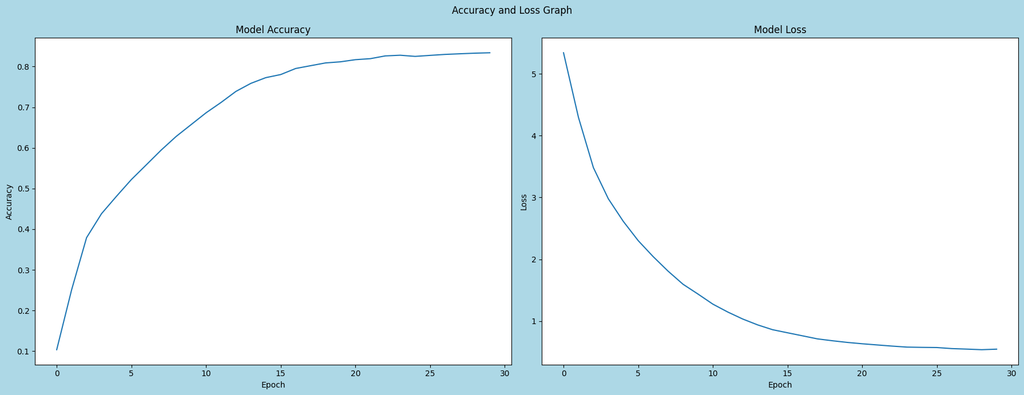

```python
from tensorflow.keras.layers import Embedding, LSTM, Dense, Dropout, LayerNormalization
from tensorflow.keras.models import Sequential
import tensorflow as tf

gpus = tf.config.experimental.list_physical_devices('GPU')
for gpu in gpus:
    tf.config.experimental.set_memory_growth(gpu, True)

# Input is max sequence length - 1, as we've removed the last word for the label.
input_len = max_sequence_len - 1

model = Sequential()

# Add input embedding layer.
model.add(Embedding(total_words, 256, input_length=input_len))

# Add LSTM layer with 256 units.
model.add(LSTM(256,return_sequences=True))
model.add(LayerNormalization())
model.add(LSTM(256))

# Control overfitting.
model.add(Dropout(0.3))

# Add output layer
model.add(Dense(total_words, activation='softmax'))
model.compile(loss='categorical_crossentropy', optimizer='adam',metrics=['accuracy'])
history = model.fit(X, y, epochs=30, verbose=1,batch_size=32)
model.save_weights("./RNN Weights/model3.h5")
plotAUC(history)
```

```python
model.summary()
```

```
Model: "sequential_58"
_________________________________________________________________
 Layer (type)                Output Shape              Param #
=================================================================
 embedding_58 (Embedding)    (None, 34, 256)           307200

 lstm_66 (LSTM)              (None, 34, 256)           525312

 layer_normalization_4 (Laye  (None, 34, 256)          512
 rNormalization)

 lstm_67 (LSTM)              (None, 256)               525312

 dropout_67 (Dropout)        (None, 256)               0

 dense_61 (Dense)            (None, 1200)              308400

=================================================================
Total params: 1,666,736
Trainable params: 1,666,736
Non-trainable params: 0
_________________________________________________________________
```

## Model 3 Evaluation

## Reference Text

```python
referenceDF = df.copy()
pointer = 0
reference_texts = []
while pointer<1000:
    reference_texts.extend((referenceDF[pointer:pointer+10]['Quotes'].values.tolist()))
    pointer += 100
reference_texts
```

```
["Embrace the beauty of every sunrise; it's a fresh chance to paint your world with joy.",
 'Embrace challenges; they are the stepping stones to your greatest victories.',
 'Embrace the rhythm of life and let it dance through your soul.',
 'Embrace kindness, for it has the power to change the world one heart at a time.',
 'Embrace the journey, for it leads to the destination of your dreams.',
 'Embrace your uniqueness, for it is the fingerprint of your soul on the universe.',
 'Embrace the present moment, for it is the only one that truly exists.',
 'Embrace your fears, for they hold the key to unlocking your true potential.',
 'Embrace gratitude, and watch how it multiplies the blessings in your life.',
 'Embrace the rain, for it nourishes the seeds of your future success.',
 'Radiate positivity, and watch how it illuminates your world.',
 'Radiate kindness, for it has the power to transform hearts and minds.',
 'Radiate love, for it is the most powerful force in the universe.',
 "Radiate gratitude, and you'll attract more blessings into your life.",
 'Radiate confidence, for it is the key to unlocking your true potential.',
 'Radiate joy, and let it light up the lives of those around you.',
 'Radiate authenticity, for it is the essence of true beauty.',
 'Radiate peace, and create a sanctuary of serenity within you.',
 'Radiate resilience, and let it be the armor that shields your heart.',
 'Radiate wisdom, for it carries the light of experience.',
 'Believe in yourself, for you are capable of greatness.',
 'Believe in yourself, and you will be unstoppable.',
 'Believe in yourself, and the world will believe in you.',
 'Believe in yourself, and you will conquer any challenge.',
 'Believe in yourself, for you hold the power within.',
 'Believe in yourself, and your dreams will take flight.',
 'Believe in yourself, and let your light shine bright.',
 'Believe in yourself, and miracles will happen.',
 'Believe in yourself, and you will find your way.',
 'Believe in yourself, and magic will follow.',
 "Life's journey is a canvas; paint it with vibrant experiences.",
 "Life's challenges are stepping stones to wisdom and growth.",
 "Life's melodies are composed of moments that touch the soul.",
 "Life's colors are brightest when painted with love and kindness.",
 "Life's adventures are the chapters that make our story extraordinary.",
 "Life's storms are followed by rainbows of hope and resilience.",
 "Life's garden blooms with the seeds of kindness we plant.",
 "Life's music is the symphony of laughter and joy.",
 "Life's whispers hold the secrets of the universe within them.",
 "Life's dance is more beautiful when we move with grace and gratitude.",
```

[output cut: 45 more lines]

```
 "Our planet's landscapes are a tapestry woven with threads of life.",
 'In the whispers of the wind, we hear the soulful song of our planet.',
 'Every tree is a testament to the strength and resilience of our planet.',
 "Our planet's oceans hold secrets and mysteries waiting to be explored.",
 'In the dance of seasons, we witness the ever-changing face of our planet.',
 'This morning holds the promise of a brand new day, full of possibilities.',
 'In the gentle embrace of this morning, we find the magic of new beginnings.',
 'This morning, let gratitude be your first thought, and joy will follow.',
 'With each sunrise, this morning paints the sky with colors of hope.',
 "This morning, let kindness be the compass guiding your day's journey.",
 "In the stillness of this morning, hear the whispers of your heart's desires.",
 'This morning, let your smile light up the world like the rising sun.',
 'With every breath this morning, inhale peace, exhale gratitude.',
 'This morning, let your actions be a testament to the goodness in your heart.',
 'In the quietude of this morning, find solace in the beauty of simplicity.']
```

## Bleu Score

```python
from rouge_score import rouge_scorer
from nltk.translate.bleu_score import sentence_bleu,SmoothingFunction
seed_texts = ['embrace each day',
 'radiate some',
 'believe that',
 "life's actual purpose is",
 'dance through each and every',
 'let your time and energy',
 'every person is',
 'our country Singapore is',
 'planet earth is',
 'morning and evening would make it']
generatedTexts = [predict_next_N_words(model,seed,10,0.8) for seed in seed_texts]
smoothie = SmoothingFunction().method1

for reference_text,generated in zip(reference_texts,generatedTexts):
    reference = [reference_text.split()]
    candidate = generated.split()
    bleuScore = sentence_bleu(reference,candidate,weights=(1,0,0,0),smoothing_function=smoothie)

    print(f"Generated Text: {generated}")
    print(f"BLEU Score: {bleuScore:.4f}\n")
```

```
Generated Text: embrace each day for it is the heartbeat of self soul and life
BLEU Score: 0.1221

Generated Text: radiate some and let it be the north star of your life
BLEU Score: 0.1667

Generated Text: believe that you will forge a path to success by the wisdom
BLEU Score: 0.0833

Generated Text: life's actual purpose is the reminders of our inner wisdom and self that resides
BLEU Score: 0.0619

Generated Text: dance through each and every day is a new chance for your potential and strength
BLEU Score: 0.1333

Generated Text: let your time and energy the legacy of your love and joy will you free
BLEU Score: 0.2667

Generated Text: every person is a reminder of the preciousness of life each touch the
BLEU Score: 0.2308

Generated Text: our country Singapore is a classroom where we learn to love and forgive forgive
BLEU Score: 0.0714

Generated Text: planet earth is a testament to the beauty of our diversity and focus
BLEU Score: 0.1538

Generated Text: morning and evening would make it is a harmonious life giving and determined to connect and
BLEU Score: 0.0625
```

## Jaccard Similarity

```python
from rouge_score import rouge_scorer
from nltk.translate.bleu_score import sentence_bleu,SmoothingFunction

# reference: https://www.educative.io/answers/what-is-the-jaccard-similarity-measure-in-nlp

def jaccardSimilarity(set1,set2):
    intersection = len(set1.intersection(set2))
    union = len(set1.union(set2))
    similarity = intersection/union if union!= 0 else 0
    return similarity


for reference_text,generated in zip(reference_texts,generatedTexts):
    reference = set(reference_text.split())
    candidate = set(generated.split())
    jaccardResult = jaccardSimilarity(reference,candidate)

    print(f"Generated Text: {generated}")
    print(f"Jaccard Similarity: {jaccardResult:.4f}\n")
```

```
Generated Text: embrace each day for it is the heartbeat of self soul and life
Jaccard Similarity: 0.0741

Generated Text: radiate some and let it be the north star of your life
Jaccard Similarity: 0.0952

Generated Text: believe that you will forge a path to success by the wisdom
Jaccard Similarity: 0.0435

Generated Text: life's actual purpose is the reminders of our inner wisdom and self that resides
Jaccard Similarity: 0.0357

Generated Text: dance through each and every day is a new chance for your potential and strength
Jaccard Similarity: 0.0870

Generated Text: let your time and energy the legacy of your love and joy will you free
Jaccard Similarity: 0.1364

Generated Text: every person is a reminder of the preciousness of life each touch the
Jaccard Similarity: 0.0952

Generated Text: our country Singapore is a classroom where we learn to love and forgive forgive
Jaccard Similarity: 0.0417

Generated Text: planet earth is a testament to the beauty of our diversity and focus
Jaccard Similarity: 0.0870

Generated Text: morning and evening would make it is a harmonious life giving and determined to connect and
Jaccard Similarity: 0.0417
```

### The Jaccard Similarity score for Model 3 ranges from 0.1364 (highest) and 0.0357 (lowest).

## Human Evaluation

### I will be assessing the generated text based on the relevance, meaningfulness and creativity corresponding to the seed text. To achieve unique generated texts, I will use the model to generate the text twice.

### First Run

```python
generatedTexts = [predict_next_N_words(model,seed,10,0.8) for seed in seed_texts]
print("First Run")
for seed,generated in zip(seed_texts,generatedTexts):
    print(f"Seed Text: {seed}")
    print(f"Generated Text: {generated}\n")
```

```
First Run
Seed Text: embrace each day
Generated Text: embrace each day for it is the most to the tranquility of the

Seed Text: radiate some
Generated Text: radiate some and let it be the bridge that mends hearts of

Seed Text: believe that
Generated Text: believe that watch the world transform around you forward of your journey

Seed Text: life's actual purpose is
Generated Text: life's actual purpose is the stepping stones to your greatest victories and passion of

Seed Text: dance through each and every
Generated Text: dance through each and every moment of the soul within our aspirations and wisdom that

Seed Text: let your time and energy
Generated Text: let your time and energy be the lighthouse in the turbulent seas of life of

Seed Text: every person is
Generated Text: every person is a reminder of the preciousness of life each day is

Seed Text: our country Singapore is
Generated Text: our country Singapore is stronger vibrant symphony and love and joy in the harmony

Seed Text: planet earth is
Generated Text: planet earth is the key to unlocking your true potential and our days

Seed Text: morning and evening would make it
Generated Text: morning and evening would make it with simplicity of love and possibility for warmth and light
```

### Upon analysing and evaluating the given seed text and generated text, it is evident that the model attempts to generate creative and imaginative continuations depending on the given prompts. Most Meaningful, Creative and Relevant: Generated Text: life's actual purpose is the stepping stones to your greatest victories and passion of Most Relevant: Generated Text: every person is a reminder of the preciousness of life each day is Less Relevant: Generated Text: planet earth is the key to unlocking your true potential and our days

### Second Run

```python
generatedTexts = [predict_next_N_words(model,seed,10,0.8) for seed in seed_texts]
print("Second Run")
for seed,generated in zip(seed_texts,generatedTexts):
    print(f"Seed Text: {seed}")
    print(f"Generated Text: {generated}\n")
```

```
Second Run
Seed Text: embrace each day
Generated Text: embrace each day for it is a reflection of the soul and self

Seed Text: radiate some
Generated Text: radiate some and let it be the anchor in the storms of

Seed Text: believe that
Generated Text: believe that you will find your way is a tribute to the

Seed Text: life's actual purpose is
Generated Text: life's actual purpose is the reminders of our inner strength and wisdom of your

Seed Text: dance through each and every
Generated Text: dance through each and every moment of gratitude for the day is a precious gift

Seed Text: let your time and energy
Generated Text: let your time and energy be your chambers and kindness that resonates with the world

Seed Text: every person is
Generated Text: every person is a reminder of the beauty in transitions and farewells in

Seed Text: our country Singapore is
Generated Text: our country Singapore is by the colors of time embrace a world around you

Seed Text: planet earth is
Generated Text: planet earth is a beacon of hope for our planet's future of our

Seed Text: morning and evening would make it
Generated Text: morning and evening would make it around you forward of compassion and kindness that every dream
```

### Most Meaningful, Creative and Relevant: Generated Text: dance through each and every moment of gratitude for the day is a precious gift Most Relevant: Generated Text: every person is a reminder of the beauty in transitions and farewells in Less Relevant: Generated Text: radiate some and let it be the anchor in the storms of

## Load Model 3

```python
from tensorflow.keras.layers import Embedding, LSTM, Dense, Dropout, LayerNormalization
from tensorflow.keras.models import Sequential
import tensorflow as tf

gpus = tf.config.experimental.list_physical_devices('GPU')
for gpu in gpus:
    tf.config.experimental.set_memory_growth(gpu, True)

# Input is max sequence length - 1, as we've removed the last word for the label.
input_len = max_sequence_len - 1

model = Sequential()

# Add input embedding layer.
model.add(Embedding(total_words, 256, input_length=input_len))

# Add LSTM layer with 256 units.
model.add(LSTM(256,return_sequences=True))
model.add(LayerNormalization())
model.add(LSTM(256))

# Control overfitting.
model.add(Dropout(0.3))

# Add output layer
model.add(Dense(total_words, activation='softmax'))
model.compile(loss='categorical_crossentropy', optimizer='adam',metrics=['accuracy'])
model.load_weights("./RNN Weights/model3.h5")
```

## Hyper parameter tuning

### We will first assess if Layer Normalization improves our model

### Added Layer Normalization

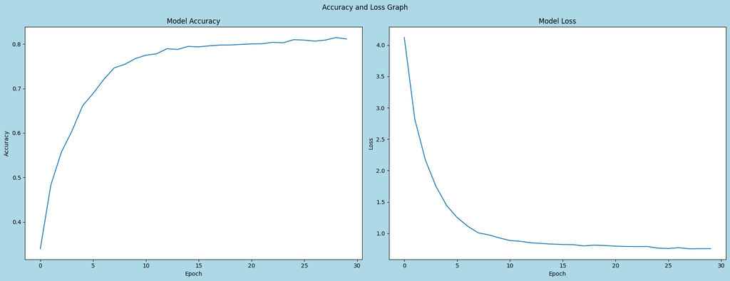

```python
from tensorflow.keras.layers import Embedding, LSTM, Dense, Dropout,GRU,Bidirectional
from tensorflow.keras.models import Sequential

import tensorflow as tf
gpus = tf.config.experimental.list_physical_devices('GPU')
for gpu in gpus:
    tf.config.experimental.set_memory_growth(gpu, True)

# Input is max sequence length - 1, as we've removed the last word for the label.
input_len = max_sequence_len - 1

model = Sequential()

# Add input embedding layer.
model.add(Embedding(total_words, 256, input_length=input_len))

model.add(Bidirectional(GRU(256,return_sequences=True)))
model.add(LayerNormalization())
model.add(Bidirectional(GRU(256)))

# Control overfitting.
model.add(Dropout(0.3))

# Add output layer
model.add(Dense(total_words, activation='softmax'))
model.compile(loss='categorical_crossentropy', optimizer='adam',metrics=['accuracy'])
history = model.fit(X, y, epochs=30, verbose=1,batch_size=32)
plotAUC(history)
```

## Evaluation (Added Layer Normalization)

## Reference Text

```python
referenceDF = df.copy()
pointer = 0
reference_texts = []
while pointer<1000:
    reference_texts.extend((referenceDF[pointer:pointer+10]['Quotes'].values.tolist()))
    pointer += 100
reference_texts
```

```
["Embrace the beauty of every sunrise; it's a fresh chance to paint your world with joy.",
 'Embrace challenges; they are the stepping stones to your greatest victories.',
 'Embrace the rhythm of life and let it dance through your soul.',
 'Embrace kindness, for it has the power to change the world one heart at a time.',
 'Embrace the journey, for it leads to the destination of your dreams.',
 'Embrace your uniqueness, for it is the fingerprint of your soul on the universe.',
 'Embrace the present moment, for it is the only one that truly exists.',
 'Embrace your fears, for they hold the key to unlocking your true potential.',
 'Embrace gratitude, and watch how it multiplies the blessings in your life.',
 'Embrace the rain, for it nourishes the seeds of your future success.',
 'Radiate positivity, and watch how it illuminates your world.',
 'Radiate kindness, for it has the power to transform hearts and minds.',
 'Radiate love, for it is the most powerful force in the universe.',
 "Radiate gratitude, and you'll attract more blessings into your life.",
 'Radiate confidence, for it is the key to unlocking your true potential.',
 'Radiate joy, and let it light up the lives of those around you.',
 'Radiate authenticity, for it is the essence of true beauty.',
 'Radiate peace, and create a sanctuary of serenity within you.',
 'Radiate resilience, and let it be the armor that shields your heart.',
 'Radiate wisdom, for it carries the light of experience.',
 'Believe in yourself, for you are capable of greatness.',
 'Believe in yourself, and you will be unstoppable.',
 'Believe in yourself, and the world will believe in you.',
 'Believe in yourself, and you will conquer any challenge.',
 'Believe in yourself, for you hold the power within.',
 'Believe in yourself, and your dreams will take flight.',
 'Believe in yourself, and let your light shine bright.',
 'Believe in yourself, and miracles will happen.',
 'Believe in yourself, and you will find your way.',
 'Believe in yourself, and magic will follow.',
 "Life's journey is a canvas; paint it with vibrant experiences.",
 "Life's challenges are stepping stones to wisdom and growth.",
 "Life's melodies are composed of moments that touch the soul.",
 "Life's colors are brightest when painted with love and kindness.",
 "Life's adventures are the chapters that make our story extraordinary.",
 "Life's storms are followed by rainbows of hope and resilience.",
 "Life's garden blooms with the seeds of kindness we plant.",
 "Life's music is the symphony of laughter and joy.",
 "Life's whispers hold the secrets of the universe within them.",
 "Life's dance is more beautiful when we move with grace and gratitude.",
```

[output cut: 45 more lines]

```
 "Our planet's landscapes are a tapestry woven with threads of life.",
 'In the whispers of the wind, we hear the soulful song of our planet.',
 'Every tree is a testament to the strength and resilience of our planet.',
 "Our planet's oceans hold secrets and mysteries waiting to be explored.",
 'In the dance of seasons, we witness the ever-changing face of our planet.',
 'This morning holds the promise of a brand new day, full of possibilities.',
 'In the gentle embrace of this morning, we find the magic of new beginnings.',
 'This morning, let gratitude be your first thought, and joy will follow.',
 'With each sunrise, this morning paints the sky with colors of hope.',
 "This morning, let kindness be the compass guiding your day's journey.",
 "In the stillness of this morning, hear the whispers of your heart's desires.",
 'This morning, let your smile light up the world like the rising sun.',
 'With every breath this morning, inhale peace, exhale gratitude.',
 'This morning, let your actions be a testament to the goodness in your heart.',
 'In the quietude of this morning, find solace in the beauty of simplicity.']
```

## Bleu Score

```python
from rouge_score import rouge_scorer
from nltk.translate.bleu_score import sentence_bleu,SmoothingFunction

seed_texts = ['embrace each day',
 'radiate some',
 'believe that',
 "life's actual purpose is",
 'dance through each and every',
 'let your time and energy',
 'every person is',
 'our country Singapore is',
 'planet earth is',
 'morning and evening would make it']
generatedTexts = [predict_next_N_words(model,seed,10,0.8) for seed in seed_texts]
smoothie = SmoothingFunction().method1

for reference_text,generated in zip(reference_texts,generatedTexts):
    reference = [reference_text.split()]
    candidate = generated.split()
    bleuScore = sentence_bleu(reference,candidate,weights=(1,0,0,0),smoothing_function=smoothie)

    print(f"Generated Text: {generated}")
    print(f"BLEU Score: {bleuScore:.4f}\n")
```

```
Generated Text: embrace each day with a heart full of gratitude for it turns ordinary
BLEU Score: 0.1832

Generated Text: radiate some and let it be the sunrise in your darkest nights
BLEU Score: 0.1667

Generated Text: believe that yourself and you will inspire others to believe too too
BLEU Score: 0.0833

Generated Text: life's actual purpose is the classroom where we learn to love and forgive reign
BLEU Score: 0.1238

Generated Text: dance through each and every breath is a gift a reminder of the marvel of
BLEU Score: 0.1333

Generated Text: let your time and energy that propels you forward for you touch every moment into
BLEU Score: 0.1333

Generated Text: every person is a promise a story worthy of your empathy of your
BLEU Score: 0.0769

Generated Text: our country Singapore is a reflection of the earth's fiery core the sea of
BLEU Score: 0.0714

Generated Text: planet earth is a reflection of the beauty in every moment of laughter
BLEU Score: 0.1538

Generated Text: morning and evening would make it the soul of our planet offers the promise of a
BLEU Score: 0.2500
```

### The BLEU score ranges from 0.25 (highest) and 0.0714 (lowest).

## Jaccard Similarity

```python
from rouge_score import rouge_scorer
from nltk.translate.bleu_score import sentence_bleu,SmoothingFunction

# reference: https://www.educative.io/answers/what-is-the-jaccard-similarity-measure-in-nlp

def jaccardSimilarity(set1,set2):
    intersection = len(set1.intersection(set2))
    union = len(set1.union(set2))
    similarity = intersection/union if union!= 0 else 0
    return similarity


for reference_text,generated in zip(reference_texts,generatedTexts):
    reference = set(reference_text.split())
    candidate = set(generated.split())
    jaccardResult = jaccardSimilarity(reference,candidate)

    print(f"Generated Text: {generated}")
    print(f"Jaccard Similarity: {jaccardResult:.4f}\n")
```

```
Generated Text: embrace each day with a heart full of gratitude for it turns ordinary
Jaccard Similarity: 0.1154

Generated Text: radiate some and let it be the sunrise in your darkest nights
Jaccard Similarity: 0.0952

Generated Text: believe that yourself and you will inspire others to believe too too
Jaccard Similarity: 0.0476

Generated Text: life's actual purpose is the classroom where we learn to love and forgive reign
Jaccard Similarity: 0.0741

Generated Text: dance through each and every breath is a gift a reminder of the marvel of
Jaccard Similarity: 0.0909

Generated Text: let your time and energy that propels you forward for you touch every moment into
Jaccard Similarity: 0.0833

Generated Text: every person is a promise a story worthy of your empathy of your
Jaccard Similarity: 0.0476

Generated Text: our country Singapore is a reflection of the earth's fiery core the sea of
Jaccard Similarity: 0.0435

Generated Text: planet earth is a reflection of the beauty in every moment of laughter
Jaccard Similarity: 0.0909

Generated Text: morning and evening would make it the soul of our planet offers the promise of a
Jaccard Similarity: 0.1364
```

## Human Evaluation

### I will be assessing the generated text based on the relevance, meaningfulness and creativity corresponding to the seed text. To achieve unique generated texts, I will use the model to generate the text twice.

### First run

```python
generatedTexts = [predict_next_N_words(model,seed,10,0.8) for seed in seed_texts]
print("First Run")
for seed,generated in zip(seed_texts,generatedTexts):
    print(f"Seed Text: {seed}")
    print(f"Generated Text: {generated}\n")
```

```
First Run
Seed Text: embrace each day
Generated Text: embrace each day with the whispers of your strength they hold the secrets

Seed Text: radiate some
Generated Text: radiate some for it is the language of the soul and let

Seed Text: believe that
Generated Text: believe that yourself and you will leave a legacy of love you

Seed Text: life's actual purpose is
Generated Text: life's actual purpose is followed by the light of our inner strength and resilience

Seed Text: dance through each and every
Generated Text: dance through each and every moment savoring the beauty it holds its dreams to connection

Seed Text: let your time and energy
Generated Text: let your time and energy the hearts of your sails and fear it present in

Seed Text: every person is
Generated Text: every person is a gem a beacon of light in the heart of

Seed Text: our country Singapore is
Generated Text: our country Singapore is an investment in its and future of witnessing harmony creating

Seed Text: planet earth is
Generated Text: planet earth is a fresh canvas paint it with vibrant strokes of kindness

Seed Text: morning and evening would make it
Generated Text: morning and evening would make it the world creating a vibrant tapestry of life leaving threads
```

### Most Meaningful, Creative and Relevant: Generated Text: life's actual purpose is followed by the light of our inner strength and resilience Most Relevant: Generated Text: embrace each day with the whispers of your strength they hold the secrets Less Relevant: Generated Text: planet earth is a fresh canvas paint it with vibrant strokes of kindness

### Second Run

```python
generatedTexts = [predict_next_N_words(model,seed,10,0.8) for seed in seed_texts]
print("Second Run")
for seed,generated in zip(seed_texts,generatedTexts):
    print(f"Seed Text: {seed}")
    print(f"Generated Text: {generated}\n")
```

```
Second Run
Seed Text: embrace each day
Generated Text: embrace each day with a grateful heart for they resonate with your journey

Seed Text: radiate some
Generated Text: radiate some and let it be the music of your soul and

Seed Text: believe that
Generated Text: believe that yourself and you will be a force of nature we

Seed Text: life's actual purpose is
Generated Text: life's actual purpose is a reflection of the wonders of the universe and wisdom

Seed Text: dance through each and every
Generated Text: dance through each and every moment of laughter is a symphony of joy in the

Seed Text: let your time and energy
Generated Text: let your time and energy the hearts of your sails and renewal will be the

Seed Text: every person is
Generated Text: every person is a fresh canvas paint for it paint the path with

Seed Text: our country Singapore is
Generated Text: our country Singapore is an investment in a brighter future in the realization of

Seed Text: planet earth is
Generated Text: planet earth is a reflection of the beauty in the heart of singapore

Seed Text: morning and evening would make it
Generated Text: morning and evening would make it the world with the rising sun let gratitude fill the
```

## Final Model

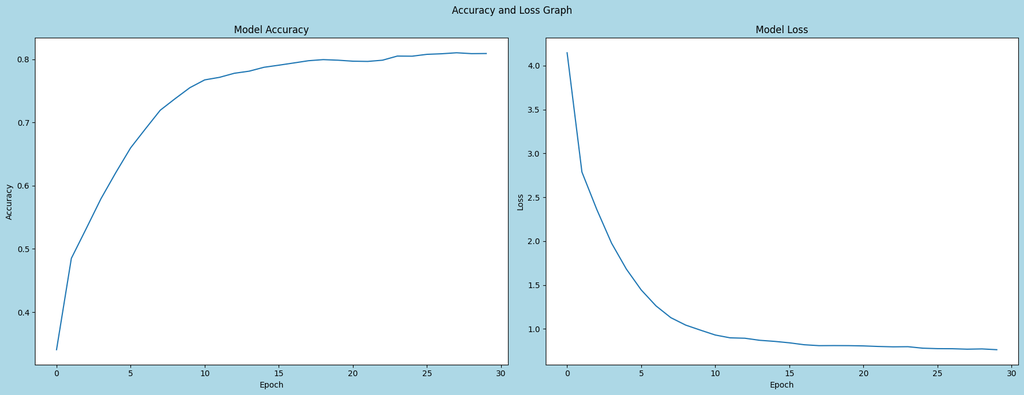

```python
from tensorflow.keras.layers import Embedding, LSTM, Dense, Dropout,GRU,Bidirectional
from tensorflow.keras.models import Sequential

import tensorflow as tf
gpus = tf.config.experimental.list_physical_devices('GPU')
for gpu in gpus:
    tf.config.experimental.set_memory_growth(gpu, True)

# Input is max sequence length - 1, as we've removed the last word for the label.
input_len = max_sequence_len - 1

model = Sequential()

# Add input embedding layer.
model.add(Embedding(total_words, 256, input_length=input_len))

model.add(Bidirectional(GRU(256,return_sequences=True)))
model.add(LayerNormalization())
model.add(Bidirectional(GRU(256)))

# Control overfitting.
model.add(Dropout(0.3))

# Add output layer
model.add(Dense(total_words, activation='softmax'))
model.compile(loss='categorical_crossentropy', optimizer='adam',metrics=['accuracy'])
history = model.fit(X, y, epochs=30, verbose=1,batch_size=32)
model.save_weights("./Best Model Weights/bestRNN.h5")
plotAUC(history)
```

```python
model.summary()
```

```
Model: "sequential_8"
_________________________________________________________________
 Layer (type)                Output Shape              Param #
=================================================================
 embedding_8 (Embedding)     (None, 34, 256)           307200

 bidirectional_8 (Bidirectio  (None, 34, 512)          789504
 nal)

 layer_normalization_4 (Laye  (None, 34, 512)          1024
 rNormalization)

 bidirectional_9 (Bidirectio  (None, 512)              1182720
 nal)

 dropout_8 (Dropout)         (None, 512)               0

 dense_8 (Dense)             (None, 1200)              615600

=================================================================
Total params: 2,896,048
Trainable params: 2,896,048
Non-trainable params: 0
_________________________________________________________________
```

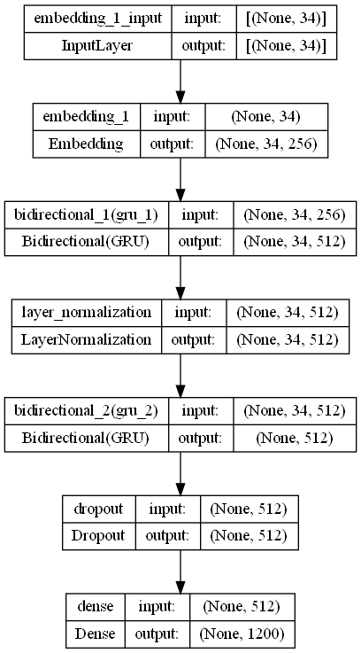

```python
from tensorflow.keras.utils import plot_model
# pip install pydot
# pip install graphviz
# conda install graphviz
# Restart kernal after installation
plot_model(model,show_shapes=True,show_layer_names=True)
```

## Load Best Model

```python
from tensorflow.keras.layers import Embedding, LSTM, Dense, Dropout,GRU,Bidirectional,LayerNormalization
from tensorflow.keras.models import Sequential

import tensorflow as tf
gpus = tf.config.experimental.list_physical_devices('GPU')
for gpu in gpus:
    tf.config.experimental.set_memory_growth(gpu, True)

# Input is max sequence length - 1, as we've removed the last word for the label.
input_len = max_sequence_len - 1

model = Sequential()

# Add input embedding layer.
model.add(Embedding(total_words, 256, input_length=input_len))

model.add(Bidirectional(GRU(256,return_sequences=True)))
model.add(LayerNormalization())
model.add(Bidirectional(GRU(256)))

# Control overfitting.
model.add(Dropout(0.3))

# Add output layer
model.add(Dense(total_words, activation='softmax'))
model.compile(loss='categorical_crossentropy', optimizer='adam',metrics=['accuracy'])
model.load_weights("./Best Model Weights/bestRNN.h5")
```